# proj_7

## Time Series Forecasting

Time series forecasting is an interesting topic in Machine Learning. It requires attention and can also be beneficial if allied to other complex topics such as stock price prediction, weather forecasting, earthquake prediction and so on. Time series forecasting is the application of a model to predict future values based on previously observed values.

Time series problem involves a time component indexing data points in time order. Exploring the data/time relationship is key to the data analysis. Among the several approaches developed over the years, Recurrent Neural Network has shown significant application on the field. Here we are going to build RNN models with Pytorch to predict Amazon stock market price.

```python
import pandas as pd
import numpy as np
import matplotlib.pyplot as plt
import yfinance as yf
from datetime import datetime
plt.style.use('seaborn')
```

### Download and Scale the Data

In this step we work on preparing the data. We download the Amazon data from the Yahoo Finance. We are particularly interested in the Close price, which are scaled (or normalized) from range $[0, +\infty]$ to range $[-1, +1]$ for next data analysis.

```python
amzn = yf.Ticker('amzn')
df = amzn.history(start='2006-01-01', end='2018-01-01')
df.head()
```

| Date | Open | High | Low | Close | Volume | Dividends | Stock Splits |
| --- | --- | --- | --- | --- | --- | --- | --- |
| 2006-01-03 | 47.470001 | 47.849998 | 46.250000 | 47.580002 | 7582200 | 0 | 0 |
| 2006-01-04 | 47.490002 | 47.730000 | 46.689999 | 47.250000 | 7440900 | 0 | 0 |
| 2006-01-05 | 47.160000 | 48.200001 | 47.110001 | 47.650002 | 5417200 | 0 | 0 |
| 2006-01-06 | 47.970001 | 48.580002 | 47.320000 | 47.869999 | 6152900 | 0 | 0 |
| 2006-01-09 | 46.549999 | 47.099998 | 46.400002 | 47.080002 | 8943100 | 0 | 0 |

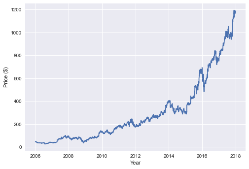

```python
plt.figure()
plt.plot(df['Close'])
plt.ylabel('Price ($)')
plt.xlabel('Year')
plt.show()
```

```python
price = df[['Close']]
price.head()
```

| Date | Close |
| --- | --- |
| 2006-01-03 | 47.580002 |
| 2006-01-04 | 47.250000 |
| 2006-01-05 | 47.650002 |
| 2006-01-06 | 47.869999 |
| 2006-01-09 | 47.080002 |

```python
from sklearn.preprocessing import MinMaxScaler

scaler = MinMaxScaler(feature_range=(-1, 1))
data_scaled = scaler.fit_transform(price['Close'].values.reshape(-1,1))
price.loc[:,'Close'] = data_scaled
```

### Set up the Training and Testing Datasets

```python
def split_data(price, seq_len, test_pct):
    data_raw = price.to_numpy() # convert to numpy array
    data = []

    # create all possible sequences of length seq_len
    for index in range(len(data_raw) - seq_len):
        data.append(data_raw[index:index + seq_len])

    data = np.array(data);
    test_set_size = int(np.round(test_pct*data.shape[0]));
    train_set_size = data.shape[0] - test_set_size;

    x_train = data[:train_set_size,:-1,:]
    y_train = data[:train_set_size,-1,:]

    x_test = data[train_set_size:,:-1,:]
    y_test = data[train_set_size:,-1,:]

    return [x_train, y_train, x_test, y_test]
```

```python
seq_len = 20 # choose a sequence length
test_pct = 0.2 # choose a ratio for testing dataset
x_train, y_train, x_test, y_test = split_data(price, seq_len, test_pct)
print('x_train.shape = ',x_train.shape)
print('y_train.shape = ',y_train.shape)
print('x_test.shape = ',x_test.shape)
print('y_test.shape = ',y_test.shape)
```

```
x_train.shape =  (2400, 19, 1)
y_train.shape =  (2400, 1)
x_test.shape =  (600, 19, 1)
y_test.shape =  (600, 1)
```

### Define and Initialize the Model

```python
import torch
import torch.nn as nn

x_train = torch.from_numpy(x_train).type(torch.Tensor)
x_test = torch.from_numpy(x_test).type(torch.Tensor)
y_train_lstm = torch.from_numpy(y_train).type(torch.Tensor)
y_test_lstm = torch.from_numpy(y_test).type(torch.Tensor)
y_train_gru = torch.from_numpy(y_train).type(torch.Tensor)
y_test_gru = torch.from_numpy(y_test).type(torch.Tensor)
```

```python
input_dim = 1
hidden_dim = 32
num_layers = 2
output_dim = 1
num_epochs = 100
```

```python
class GRU(nn.Module):
    def __init__(self, input_dim, hidden_dim, num_layers, output_dim):
        super(GRU, self).__init__()
        self.hidden_dim = hidden_dim
        self.num_layers = num_layers

        self.gru = nn.GRU(input_dim, hidden_dim, num_layers, batch_first=True)
        self.fc = nn.Linear(hidden_dim, output_dim)

    def forward(self, x):
        h0 = torch.zeros(self.num_layers, x.size(0), self.hidden_dim).requires_grad_()
        out, (hn) = self.gru(x, (h0.detach()))
        out = self.fc(out[:, -1, :])
        return out
```

```python
model = GRU(input_dim=input_dim, hidden_dim=hidden_dim, output_dim=output_dim, num_layers=num_layers)
criterion = torch.nn.MSELoss(reduction='mean')
optimiser = torch.optim.Adam(model.parameters(), lr=0.01)
```

### Train the Model

```python
import time

hist = np.zeros(num_epochs)
start_time = time.time()
gru = []

for t in range(num_epochs):
    y_train_pred = model(x_train)

    loss = criterion(y_train_pred, y_train_gru)
    if t%5 == 0:
        print("Epoch ", t, "MSE: ", loss.item())
    hist[t] = loss.item()

    optimiser.zero_grad()
    loss.backward()
    optimiser.step()

training_time = time.time()-start_time
print(f"Training time: {training_time:.6f}")
```

```
Epoch  0 MSE:  0.5910919308662415
Epoch  5 MSE:  0.02572403848171234
Epoch  10 MSE:  0.026858456432819366
Epoch  15 MSE:  0.026742029935121536
Epoch  20 MSE:  0.0284230075776577
Epoch  25 MSE:  0.018879476934671402
Epoch  30 MSE:  0.010334868915379047
Epoch  35 MSE:  0.004268634133040905
Epoch  40 MSE:  0.0027821511030197144
Epoch  45 MSE:  0.001256735878996551
Epoch  50 MSE:  0.0007425331277772784
Epoch  55 MSE:  0.0008625418995507061
Epoch  60 MSE:  0.000517804641276598
Epoch  65 MSE:  0.00020481219689827412
Epoch  70 MSE:  0.00026666471967473626
Epoch  75 MSE:  0.0002399763761786744
Epoch  80 MSE:  0.00016475692973472178
Epoch  85 MSE:  0.00017918861703947186
Epoch  90 MSE:  0.00015568526578135788
Epoch  95 MSE:  0.00014983475557528436
Training time: 22.556669
```

### Inversely Scale the Data from Range $[-1, +1]$ to Range $[0, +\infty]$

```python
# make predictions
y_test_pred = model(x_test)

# inversely scale data
y_train_pred = scaler.inverse_transform(y_train_pred.detach().numpy())
y_train = scaler.inverse_transform(y_train_gru.detach().numpy())
y_test_pred = scaler.inverse_transform(y_test_pred.detach().numpy())
y_test = scaler.inverse_transform(y_test_gru.detach().numpy())
```

### Plot Observed Values VS Predicted Values using Training Dataset

Training dataset contains 2400 time series.

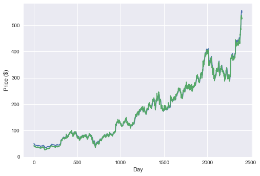

```python
df = pd.DataFrame()
df['predicted'] = pd.DataFrame(y_train_pred)
df['observerd'] = pd.DataFrame(y_train)
plt.figure()
plt.plot(df)
plt.ylabel('Price ($)')
plt.xlabel('Day')
plt.show()
```

### Plot Observed Values VS Predicted Values using Testing Dataset

Testing dataset contains 600 time series.

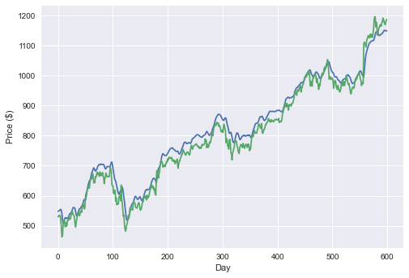

```python
df = pd.DataFrame()
df['predicted'] = pd.DataFrame(y_test_pred)
df['observerd'] = pd.DataFrame(y_test)
plt.figure()
plt.plot(df)
plt.ylabel('Price ($)')
plt.xlabel('Day')
plt.show()
```